# fullAnalysis

## Imports

```python
import shap
import IPython
import os
import sys
import numpy as np
import pandas as pd
import seaborn as sns
import matplotlib.pyplot as plt
from hashlib import sha1
import math

from sklearn.dummy import DummyRegressor
from sklearn.tree import DecisionTreeRegressor, plot_tree
from sklearn.linear_model import LogisticRegression, Ridge
from sklearn.neighbors import KNeighborsRegressor
from sklearn.ensemble import RandomForestRegressor, GradientBoostingRegressor
from sklearn.svm import SVR

from sklearn.compose import ColumnTransformer
from sklearn.pipeline import Pipeline, make_pipeline
from sklearn.preprocessing import StandardScaler, OrdinalEncoder, FunctionTransformer, OneHotEncoder
from sklearn.feature_extraction.text import CountVectorizer
from sklearn.base import BaseEstimator, TransformerMixin

from sklearn.model_selection import (
    GridSearchCV,
    cross_val_score,
    cross_validate,
    train_test_split,
    KFold,
)

from sklearn.metrics import mean_squared_error, mean_absolute_error, r2_score, make_scorer, root_mean_squared_error
```

## Dataset and Initial analysis

We have choose to do a machine learning regression analysis on [dataset](https://www.kaggle.com/dgomonov/new-york-city-airbnb-open-data) of New York City Airbnb listings from 2019. We will try to predict `reviews_per_month`, as a proxy for the popularity of the listing.

We are interested in conducting a ML experiment on real-world data which a company could potentially use as insight for their operations. Using regression may provide a little more insight rather than classification.

Our initial thoughts on the dataset are: (1) There may be some redundancy in the features (specifically in regard to the neighborhood area, neighborhood location, longitude and latitude) (2) host_name we feel is not useful but host_id could be used to see if hosts has any affect on popularity. (4) last_review is a date feature and will likely need to be transformed into a new feature like days_since_last_review. (5) Most of the numeric features seem useful and will just need to be standardized. (6) Finally we think ordinally encoding the room_type feature may provide benifical insights.

```python
PATH = "data/AB_NYC_2019.csv"
df = pd.read_csv(PATH)
```

## 2. Data splitting

```python
train_df, test_df = train_test_split(df, test_size=0.3, random_state=123)
```

## 3. EDA

Before any feature engineering or selection, we have chosen to drop the following features: id, host_name and host_id as they are not relevant to the model. (Note: host_id may provide interesting details if engineered properly (example: number_of_reviews/host_id), but we chose not to pursue that route).

From Table 1 we can see that the features with missing values are name, last_review and reviews_per_month. Additonally, we found that every time number_of_reviews was 0, reviews_per_month was NaN. Indicating that reviews_per_month should be 0 in these cases. We did this imputation before visualizing the data any further.

Table 2 shows that for all numeric features, except longitude and latitude, the standard deviation is relatively high in comparison to the mean (standard deviation is at least equal to the mean), indicating there are many outliers. This is further supported by the relatively high max values of each feature (compared to its respective mean), indicating right-skewed data (Table 2).

This is also seen in the box plots in Figure 1: showing that 'price', 'minimum_nights', 'number_of_reviews', 'reviews_per_month' and 'calculated_host_listings_count' have significant positive outliers. Longitude and latitude had outliers in both directions, while availability_365 had neither.

Figure 2 shows the distribution of the numerical features. All except the longitude and latitude are heavily right-skewed. Figure 3 shows the distribution of the numerical features with upper outliers after the outliers are removed. Figure 3 shows an improved distribution, but it is still right-skewed and thus even after outlier removal, log-transformation will still be necessary.

We will use RMSE to evaluate the average prediction error in the same units as the target. We may also use R-squared to assess how much of the variance in the target is explained by the model. This combination provides both absolute and relative performance insight.

```python
BOLD = '\033[1m'
END = '\033[0m'

numerical_features = [
    'price',
    'minimum_nights',
    'number_of_reviews',
    'reviews_per_month',
    'calculated_host_listings_count',
    'availability_365',
    'latitude',
    'longitude']

features_with_upper_outliers = ['price',
                'minimum_nights',
                'number_of_reviews',
                'calculated_host_listings_count',
                'reviews_per_month']

numerical_features_to_log = [
    'price',
    'minimum_nights',
    'number_of_reviews',
    'reviews_per_month',
    'calculated_host_listings_count',
    'availability_365']

categorical_features = ['neighbourhood_group', 'neighbourhood', 'room_type']


# Generative AI (chatGPT) used to turn the code for a figure into a reusable function.
# Prompt "From this code [code for the plot given] create a reusable function"
def plot_feature_distributions(df, feature_list, title, n_cols=2, bins=30):
    n_features = len(feature_list)
    n_rows = math.ceil(n_features / n_cols)  # automatically compute rows

    fig, axes = plt.subplots(n_rows, n_cols, figsize=(7*n_cols, 4*n_rows))
    axes = axes.flatten()  # flatten in case of multi-row/column grid

    for i, col in enumerate(feature_list):
        sns.histplot(data=df, x=col, bins=bins, kde=True, ax=axes[i])
        axes[i].set_title(f'Distribution of {col.capitalize()}', fontsize=14)
        axes[i].set_xlabel(col.capitalize())
        axes[i].set_ylabel('Frequency')

    # Turn off any unused subplots
    for j in range(i+1, len(axes)):
        axes[j].set_visible(False)

    # Figure title
    plt.figtext(0.5, 0.01, title, ha='center', va='center',
                fontsize=16, fontweight='bold')
    plt.tight_layout(rect=[0, 0.05, 1, 0.95])
    plt.show()


# Generative AI (chatGPT) used to help create this function.
# Prompt "Create a function to remove upper outliers of features using IQR"
def remove_upper_outliers_iqr(df, cols, k=1.5, verbose=True):
    filter_total = pd.Series(True, index=df.index)

    for col in cols:
        if col not in df.columns:
            continue  # skip columns that don't exist
        Q1 = df[col].quantile(0.25)
        Q3 = df[col].quantile(0.75)
        IQR = Q3 - Q1
        upper_bound = Q3 + k * IQR
        filter_col = df[col] <= upper_bound
        filter_total &= filter_col

    filtered_df = df[filter_total]

    return filtered_df
```

```python
# Make copy of the training data for EDA
df_eda = train_df.copy()
df_eda.drop(columns=['id', 'host_name', 'host_id'], inplace=True)
```

```python
# Table 1: Features with Missing Values
print(BOLD + "Table 1: Features with Missing Values" + END + "\n")
miss = df_eda.isnull().sum().sort_values(ascending=False)
display(miss.head(10))

# Investigate when reviews_per_month is NaN
missing_mask = df_eda['reviews_per_month'].isna()
count_zero_reviews = (df_eda.loc[missing_mask, 'number_of_reviews'] == 0).sum()
print(f"Number of times when reviews_per_month is NaN that number_of_reviews is 0: {count_zero_reviews}")
print("\n")

# Table 2: Dataset Summary Statistics
print("\n" + BOLD + "Table 2: Dataset Summary Statistics" + END + "\n")
display(df_eda.describe(include='all'))
```

```
Table 1: Features with Missing Values
```

```
last_review            6990
reviews_per_month      6990
name                     10
neighbourhood_group       0
neighbourhood             0
latitude                  0
longitude                 0
room_type                 0
price                     0
minimum_nights            0
dtype: int64
```

```
Number of times when reviews_per_month is NaN that number_of_reviews is 0: 6990



Table 2: Dataset Summary Statistics
```

|  | name | neighbourhood_group | neighbourhood | latitude | longitude | room_type | price | minimum_nights | number_of_reviews | last_review | reviews_per_month | calculated_host_listings_count | availability_365 |
| --- | --- | --- | --- | --- | --- | --- | --- | --- | --- | --- | --- | --- | --- |
| count | 34216 | 34226 | 34226 | 34226.000000 | 34226.000000 | 34226 | 34226.000000 | 34226.000000 | 34226.000000 | 27236 | 27236.000000 | 34226.000000 | 34226.000000 |
| unique | 33662 | 5 | 218 | NaN | NaN | 3 | NaN | NaN | NaN | 1676 | NaN | NaN | NaN |
| top | Home away from home | Manhattan | Williamsburg | NaN | NaN | Entire home/apt | NaN | NaN | NaN | 2019-06-23 | NaN | NaN | NaN |
| freq | 14 | 15176 | 2728 | NaN | NaN | 17848 | NaN | NaN | NaN | 984 | NaN | NaN | NaN |
| mean | NaN | NaN | NaN | 40.729142 | -73.952083 | NaN | 151.528399 | 7.094957 | 23.244814 | NaN | 1.369816 | 7.042453 | 112.526004 |
| std | NaN | NaN | NaN | 0.054531 | 0.046201 | NaN | 236.628392 | 21.548290 | 44.573323 | NaN | 1.700737 | 32.590803 | 131.420031 |
| min | NaN | NaN | NaN | 40.506410 | -74.244420 | NaN | 0.000000 | 1.000000 | 0.000000 | NaN | 0.010000 | 1.000000 | 0.000000 |
| 25% | NaN | NaN | NaN | 40.690193 | -73.983030 | NaN | 69.000000 | 1.000000 | 1.000000 | NaN | 0.190000 | 1.000000 | 0.000000 |
| 50% | NaN | NaN | NaN | 40.723240 | -73.955550 | NaN | 106.000000 | 3.000000 | 5.000000 | NaN | 0.710000 | 1.000000 | 45.000000 |
| 75% | NaN | NaN | NaN | 40.763287 | -73.936270 | NaN | 175.000000 | 5.000000 | 23.000000 | NaN | 2.000000 | 2.000000 | 225.750000 |
| max | NaN | NaN | NaN | 40.912340 | -73.712990 | NaN | 10000.000000 | 1250.000000 | 629.000000 | NaN | 58.500000 | 327.000000 | 365.000000 |

```python
# As found above, reviews_per_month is missing ONLY when number_of_reviews is 0
# We will fill these missing values with 0
df_eda.fillna({'reviews_per_month': 0}, inplace=True)
```

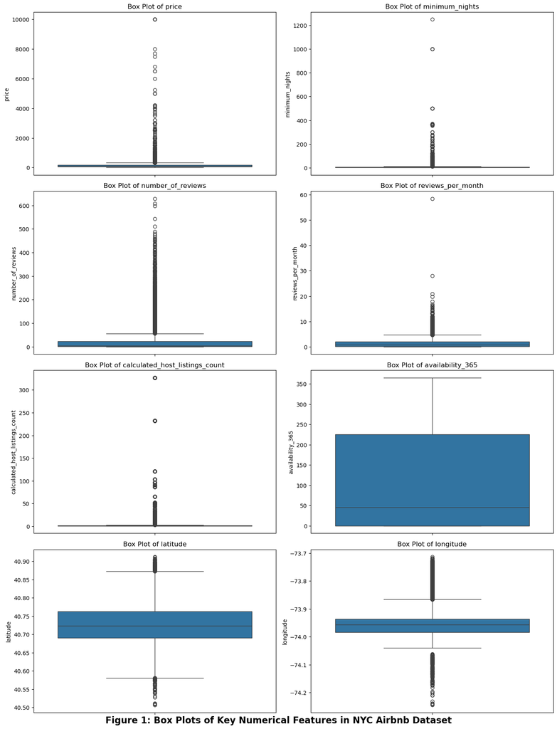

```python
# Box Plots of Numerical Features to visualize outliers
plt.figure(figsize=(14, 18))
for i, feature in enumerate(numerical_features):
    plt.subplot(4, 2, i + 1)
    sns.boxplot(data=train_df, y=feature)
    plt.title(f'Box Plot of {feature}')
    plt.ylabel(feature)
plt.tight_layout()
plt.figtext(0.5, 0, 'Figure 1: Box Plots of Key Numerical Features in NYC Airbnb Dataset',
            ha='center', va='center', fontsize=16, fontweight='bold')
plt.show()
```

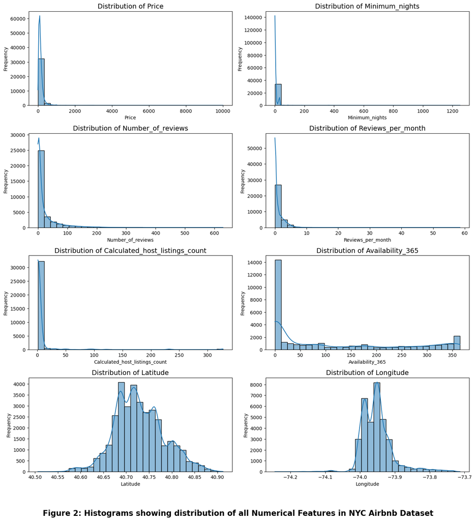

```python
title = 'Figure 2: Histograms showing distribution of all Numerical Features in NYC Airbnb Dataset'
plot_feature_distributions(df_eda, numerical_features, title)
```

```python
df_eda_filtered = remove_upper_outliers_iqr(df_eda, features_with_upper_outliers, k=3, verbose=True)
```

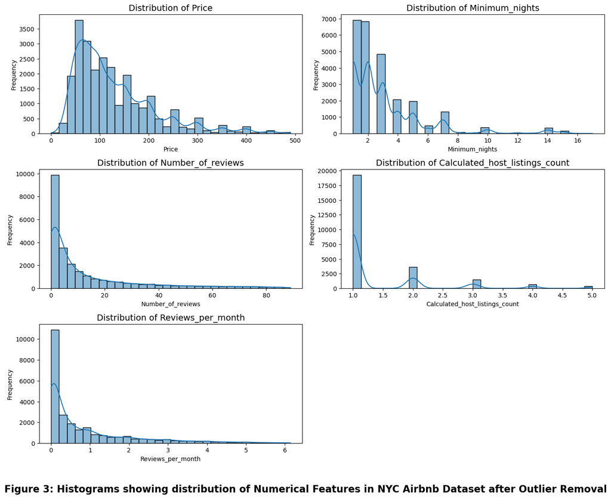

```python
title2 = 'Figure 3: Histograms showing distribution of Numerical Features in NYC Airbnb Dataset after Outlier Removal'
plot_feature_distributions(df_eda_filtered, features_with_upper_outliers, title2)
```

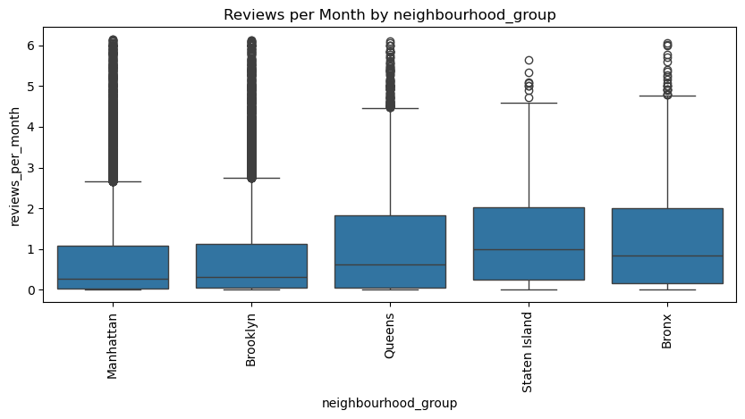

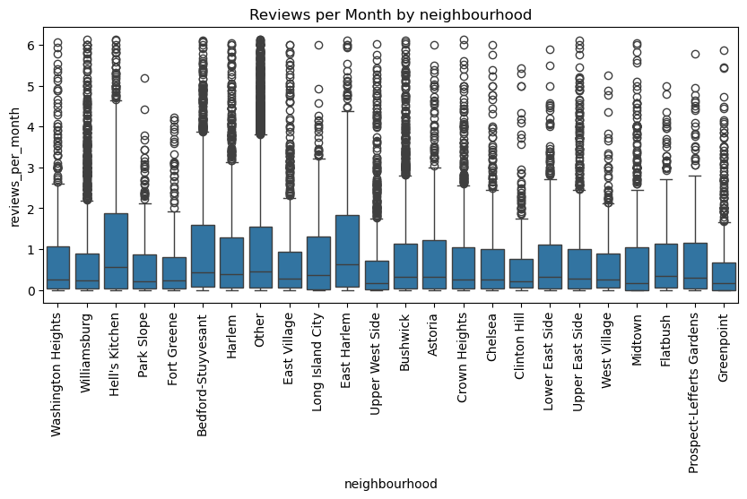

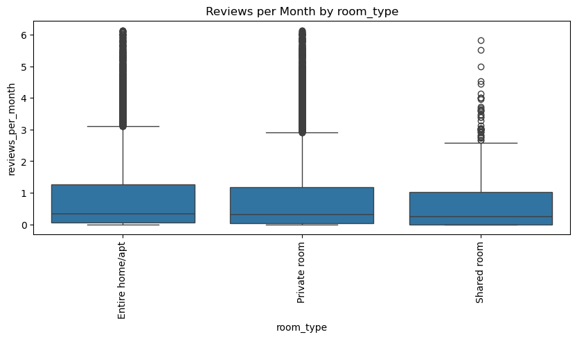

```
Figure 4: Reviews per Month by Categorical Features
```

```python
# Since there where so many neighbourhoods, we will group the rare ones into "Other" based on a threshold
# of 1% frequency.
threshold = 0.01
counts = df_eda_filtered['neighbourhood'].value_counts(normalize=True)
rare_neigh = counts[counts < threshold].index
df_eda_filtered['neighbourhood_grouped'] = df_eda_filtered['neighbourhood'].apply(
    lambda x: 'Other' if x in rare_neigh else x
)
df_eda_filtered = df_eda_filtered.drop(columns=['neighbourhood'])
df_eda_filtered = df_eda_filtered.rename(columns={'neighbourhood_grouped': 'neighbourhood'})


for col in categorical_features:
    plt.figure(figsize=(10,4))
    sns.boxplot(x=col, y='reviews_per_month', data=df_eda_filtered)
    plt.title(f"Reviews per Month by {col}")
    plt.xticks(rotation=90)
    plt.show()
print(BOLD + "Figure 4: Reviews per Month by Categorical Features" + END + "\n")
```

## 4. Feature engineering

The code for the feature engineering, the columnTransformer and the pipelines are in the preproccessing and transformation section.

Here is a summary of how we will treat the data (some of this was addressed in the EDA)

- Impute NaN's in reviews_per_month to 0.
- Any category in neighbourhood with a frequecny of less than 1% will be grouped into 'other'
- Engineer new features from last_review and then drop last_review.

## 5. Preprocessing and transformations

```python
features_with_upper_outliers = [
    'price',
    'minimum_nights',
    'number_of_reviews',
    'calculated_host_listings_count'
]

numerical_features = [
    'price',
    'minimum_nights',
    'number_of_reviews',
    'calculated_host_listings_count',
    'availability_365',
    'latitude',
    'longitude'
]

numerical_features_to_log = [
    'price',
    'minimum_nights',
    'number_of_reviews',
    'calculated_host_listings_count',
    'availability_365'
]

date_feature = ['last_review']

categorical_features = ['neighbourhood_group', 'neighbourhood', 'room_type']
```

```python
# Since we are imputing the target variable to be 0, and dropping columns/rows,
# I will redo the train test split here.

df2 = pd.read_csv(PATH)
# Drop unnecessary features
df2 = df2.drop(columns=['id', 'host_id', 'host_name'])
# Impute target variable
df2['reviews_per_month'] = df2['reviews_per_month'].fillna(0)
train_df, test_df = train_test_split(df2, test_size=0.3, random_state=123)

# Remove outliers from training data
train_df = remove_upper_outliers_iqr(train_df, features_with_upper_outliers, k=3, verbose=True)

X_train = train_df.drop(columns=['reviews_per_month'])
y_train = train_df['reviews_per_month']

X_test = test_df.drop(columns=['reviews_per_month'])
y_test = test_df['reviews_per_month']
```

```python
# Custom skileartransformer classes
# n Used chatGPT to help create these custom transformers
# I had the code to do these transformations, but wanted to make them reusable
# Prompt: "From this code [code for the transformation given] create a sklearn transformer class"

class DateTransformer(BaseEstimator, TransformerMixin):
    """Creates 'days_since_last_review' and 'never_reviewed' features."""
    def __init__(self, reference_date=pd.Timestamp('2019-07-08')):
        self.reference_date = reference_date

    def fit(self, X, y=None):
        return self

    def transform(self, X):
        X = X.copy()
        last_review = pd.to_datetime(X['last_review'], errors='coerce')

        # Feature 1: Days since last review
        days_since = (self.reference_date - last_review).dt.days
        days_since = days_since.fillna(days_since.max())  # Fill NaNs with max (meaning: never reviewed)

        # Feature 2: Never reviewed flag
        never_reviewed = last_review.isna().astype(int)

        return pd.DataFrame({
            'days_since_last_review': days_since,
            'never_reviewed': never_reviewed
        })

class RareCategoryGrouper(BaseEstimator, TransformerMixin):
    """Groups rare categories (< threshold fraction) into 'Other'."""
    def __init__(self, threshold=0.01):
        self.threshold = threshold

    def fit(self, X, y=None):
        # Ensure X is a DataFrame
        X = pd.DataFrame(X)
        # Store common categories for each column
        self.common_ = {}
        for col in X.columns:
            freq = X[col].value_counts(normalize=True)
            self.common_[col] = freq[freq >= self.threshold].index.tolist()
        return self

    def transform(self, X):
        X = pd.DataFrame(X).copy()
        for col in X.columns:
            X[col] = X[col].apply(lambda val: val if val in self.common_[col] else 'Other')
        return X

def selective_log_transform(X):
    X = X.copy()
    for col in X.columns:
        if col in numerical_features_to_log:
            X[col] = np.log1p(X[col])  # log(1+x)
    return X
```

```python
num_pipeline = Pipeline(steps=[
    ('log', FunctionTransformer(selective_log_transform, validate=False, feature_names_out="one-to-one")),
    ('scaler', StandardScaler())
])

cat_pipeline = ColumnTransformer(transformers=[
    ('neigh_group', Pipeline([
        ('onehot', OneHotEncoder(handle_unknown='ignore'))
    ]), ['neighbourhood_group']),

    ('neigh', Pipeline([
        ('rare_grouper', RareCategoryGrouper(threshold=0.01)),  # use the new class here
        ('onehot', OneHotEncoder(handle_unknown='ignore'))
    ]), ['neighbourhood']),

    ('room', Pipeline([
        ('onehot', OneHotEncoder(handle_unknown='ignore'))
    ]), ['room_type'])
])

# Make new feature from last_review, but only scale days_since_last_review
date_pipeline = Pipeline([
    ('date_features', DateTransformer()),
    ('split_features', ColumnTransformer([
        ('scale_days', StandardScaler(), ['days_since_last_review']),
        ('keep_flag', 'passthrough', ['never_reviewed'])
    ]))
])

preprocessor = ColumnTransformer(transformers=[
    ('num', num_pipeline, numerical_features),
    ('cat', cat_pipeline, categorical_features),
    ('date', date_pipeline, date_feature)
])
```

## 6. Baseline model

```python
dummy_regressor = DummyRegressor(strategy='mean')
dummy_regressor.fit(X_train, y_train)
y_pred_dummy = dummy_regressor.predict(X_test)
```

```python
mse = mean_squared_error(y_test, y_pred_dummy)
rmse = np.sqrt(mse)
mae = mean_absolute_error(y_test, y_pred_dummy)
r2 = r2_score(y_test, y_pred_dummy)

print(BOLD + "Table 3: Baseline DummyRegressor performance with mean strategy:\n" + END)
print(f"  MAE  = {mae:.4f}")
print(f"  RMSE = {rmse:.4f}")
print(f"  R²   = {r2:.4f}")
```

```
Table 3: Baseline DummyRegressor performance with mean strategy:

  MAE  = 1.1066
  RMSE = 1.5623
  R²   = -0.0077
```

These results indicate that, on average, the baseline predictions are off by about 1.1066 reviews per month, and some listings deviate further from the mean, as reflected by the higher RMSE of 1.5623. The negative R² shows that this naive model performs slightly worse than simply predicting the mean of the test set. This baseline provides a minimum performance standard, and any model using feature engineering and preprocessing should outperform it, achieving lower error and a positive R².

## 7. Linear models

```python
ridge_pipeline = Pipeline([
    ('preprocess', preprocessor),
    ('regressor', Ridge())
])
scoring = {
    'rmse': 'neg_mean_squared_error',
    'r2': 'r2'
}
param_grid = {'regressor__alpha': [0.001, 0.01, 0.1, 0.5, 1, 5, 10, 25, 50, 75, 100, 500]}
kf = KFold(n_splits=5, shuffle=True, random_state=42)

ridge_gridSearch = GridSearchCV(ridge_pipeline, param_grid, cv=kf,
                                scoring=scoring, refit='rmse',
                                return_train_score=True,
                                n_jobs=-1)
results = ridge_gridSearch.fit(X_train, y_train)
```

```python
cv_results_df = pd.DataFrame(ridge_gridSearch.cv_results_)

# Add RMSE (take sqrt of mean_test_score)
cv_results_df['mean_test_rmse'] = np.sqrt(-cv_results_df['mean_test_rmse'])
cv_results_df['std_test_rmse'] = np.sqrt(cv_results_df['std_test_rmse'])

# Select only relevant columns
print(BOLD + "\nTable 4: Ridge Regression Grid Search CV Results for alpha\n" + END)
display_columns = ['param_regressor__alpha', 'mean_test_rmse', 'std_test_rmse', 'mean_test_r2', 'std_test_r2']
cv_results_df[display_columns]
```

```
Table 4: Ridge Regression Grid Search CV Results for alpha
```

|  | param_regressor__alpha | mean_test_rmse | std_test_rmse | mean_test_r2 | std_test_r2 |
| --- | --- | --- | --- | --- | --- |
| 0 | 0.001 | 1.075788 | 0.186307 | 0.421829 | 0.012731 |
| 1 | 0.010 | 1.075786 | 0.186310 | 0.421831 | 0.012729 |
| 2 | 0.100 | 1.075779 | 0.186314 | 0.421838 | 0.012723 |
| 3 | 0.500 | 1.075744 | 0.186367 | 0.421877 | 0.012695 |
| 4 | 1.000 | 1.075708 | 0.186375 | 0.421917 | 0.012652 |
| 5 | 5.000 | 1.075407 | 0.186638 | 0.422248 | 0.012358 |
| 6 | 10.000 | 1.075077 | 0.187012 | 0.422612 | 0.012003 |
| 7 | 25.000 | 1.074315 | 0.188296 | 0.423456 | 0.011079 |
| 8 | 50.000 | 1.073630 | 0.190605 | 0.424226 | 0.009904 |
| 9 | 75.000 | 1.073451 | 0.192878 | 0.424446 | 0.009066 |
| 10 | 100.000 | 1.073591 | 0.194925 | 0.424319 | 0.008466 |
| 11 | 500.000 | 1.083317 | 0.208508 | 0.413948 | 0.007001 |

The Ridge regression model was trained with a range of alpha values from 0.001 to 500, performing 5-fold cross-validation for each. The results show that an alpha of 75 produced the best performance, having the lowest mean CV RMSE of 1.0734 and the highest mean R² of 0.4244 (Table 4). The standard deviation for the RMSE was 0.19, indicating relative stability (Table 4). Alpha values higher or lower than 75 increased the RMSE and decreased the R², showing underfitting.

## 8. Different models

```python
rmse_scorer = make_scorer(root_mean_squared_error)
kf = KFold(n_splits=5, shuffle=True, random_state=42)
```

```python
# Model: Random Forest Regressor
rf_pipeline = Pipeline([
    ('preprocess', preprocessor),
    ('regressor', RandomForestRegressor(n_estimators=5, random_state=42))
])

results_rf = []

rf_cv = cross_validate(
    rf_pipeline, X_train, y_train,
    scoring={'rmse': rmse_scorer, 'r2': 'r2'},
    cv=kf,
    return_train_score=True,
    n_jobs=-1
)


results_rf.append({
    'Model': 'RandomForest',
    'Mean RMSE': np.mean(rf_cv['test_rmse']),
    'Std RMSE': np.std(rf_cv['test_rmse']),
    'Mean Train RMSE': np.mean(rf_cv['train_rmse']),
    'Mean CV R²': np.mean(rf_cv['test_r2']),
    'Std CV R²': np.std(rf_cv['test_r2']),
    'Fit Time': np.mean(rf_cv['fit_time']),
    'Score Time': np.mean(rf_cv['score_time'])
})
```

```python
results_rf = pd.DataFrame(results_rf)
print(BOLD + "\nTable 5: Random Forest Regressor CV Results\n" + END)
results_rf
```

```
Table 5: Random Forest Regressor CV Results
```

|  | Model | Mean RMSE | Std RMSE | Mean Train RMSE | Mean CV R² | Std CV R² | Fit Time | Score Time |
| --- | --- | --- | --- | --- | --- | --- | --- | --- |
| 0 | RandomForest | 0.942417 | 0.015503 | 0.436172 | 0.556081 | 0.014768 | 11.516369 | 0.051627 |

```python
# Model 2: Gradient Boosting Regressor
gb_pipeline = Pipeline([
    ('preprocess', preprocessor),
    ('regressor', GradientBoostingRegressor(n_estimators=20, learning_rate=0.1, random_state=42))
])

results_gb = []

gb_cv = cross_validate(
    gb_pipeline, X_train, y_train,
    scoring={'rmse': rmse_scorer, 'r2': 'r2'},
    cv=kf,
    return_train_score=True,
    n_jobs=-1
)

results_gb.append({
    'Model': 'GradientBoosting',
    'Mean RMSE': np.mean(gb_cv['test_rmse']),
    'Std RMSE': np.std(gb_cv['test_rmse']),
    'Mean Train RMSE': np.mean(gb_cv['train_rmse']),
    'Mean CV R²': np.mean(gb_cv['test_r2']),
    'Std CV R²': np.std(gb_cv['test_r2']),
    'Fit Time': np.mean(gb_cv['fit_time']),
    'Score Time': np.mean(gb_cv['score_time'])
})
```

```python
results_gb = pd.DataFrame(results_gb)
print(BOLD + "\nTable 6: Gradient Boosting Regressor CV Results\n" + END)
results_gb
```

```
Table 6: Gradient Boosting Regressor CV Results
```

|  | Model | Mean RMSE | Std RMSE | Mean Train RMSE | Mean CV R² | Std CV R² | Fit Time | Score Time |
| --- | --- | --- | --- | --- | --- | --- | --- | --- |
| 0 | GradientBoosting | 0.904498 | 0.018064 | 0.899838 | 0.591341 | 0.004376 | 1.977013 | 0.089021 |

```python
# Model 3: K-Nearest Neighbors Regressor

results_knn = []

knn_pipeline = Pipeline([
    ('preprocess', preprocessor),
    ('regressor', KNeighborsRegressor(n_neighbors=5))
])

knn_cv = cross_validate(
    knn_pipeline, X_train, y_train,
    scoring={'rmse': rmse_scorer, 'r2': 'r2'},
    cv=kf,
    return_train_score=True,
    n_jobs=-1
)

results_knn.append({
    'Model': 'KNN',
    'Mean RMSE': np.mean(knn_cv['test_rmse']),
    'Std RMSE': np.std(knn_cv['test_rmse']),
    'Mean Train RMSE': np.mean(knn_cv['train_rmse']),
    'Mean CV R²': np.mean(knn_cv['test_r2']),
    'Std CV R²': np.std(knn_cv['test_r2']),
    'Fit Time': np.mean(knn_cv['fit_time']),
    'Score Time': np.mean(knn_cv['score_time'])
})
```

```python
results_knn = pd.DataFrame(results_knn)
print(BOLD + "\nTable 7: K-Nearest Neighbors CV Results\n" + END)
results_knn
```

```
Table 7: K-Nearest Neighbors CV Results
```

|  | Model | Mean RMSE | Std RMSE | Mean Train RMSE | Mean CV R² | Std CV R² | Fit Time | Score Time |
| --- | --- | --- | --- | --- | --- | --- | --- | --- |
| 0 | KNN | 1.085391 | 0.017073 | 0.881811 | 0.411345 | 0.012748 | 0.441588 | 50.70278 |

```python
results_svr = []

svr_pipeline = Pipeline([
    ('preprocess', preprocessor),
    ('regressor', SVR(kernel='rbf', C=1.0, epsilon=0.1))
])

svr_cv = cross_validate(
    svr_pipeline, X_train, y_train,
    scoring={'rmse': rmse_scorer, 'r2': 'r2'},
    cv=kf,
    return_train_score=True,
    n_jobs=-1
)

results_svr.append({
    'Model': 'SVR',
    'Mean RMSE': np.mean(svr_cv['test_rmse']),
    'Std RMSE': np.std(svr_cv['test_rmse']),
    'Mean Train RMSE': np.mean(svr_cv['train_rmse']),
    'Mean CV R²': np.mean(svr_cv['test_r2']),
    'Std CV R²': np.std(svr_cv['test_r2']),
    'Fit Time': np.mean(svr_cv['fit_time']),
    'Score Time': np.mean(svr_cv['score_time'])
})
```

```python
results_svr = pd.DataFrame(results_svr)
print(BOLD + "\nTable 8: Support Vector Regressor CV Results\n" + END)
results_svr
```

```
Table 8: Support Vector Regressor CV Results
```

|  | Model | Mean RMSE | Std RMSE | Mean Train RMSE | Mean CV R² | Std CV R² | Fit Time | Score Time |
| --- | --- | --- | --- | --- | --- | --- | --- | --- |
| 0 | SVR | 0.994893 | 0.022285 | 0.971542 | 0.505532 | 0.01106 | 34.123144 | 5.414588 |

Cross-validation on the training data showed clear differences in generalization, overfitting, and runtime. Gradient boosting achieved the best performance, with a mean CV RMSE of about 0.905 and mean CV R² of about 0.591, and its mean train RMSE was almost the same as its mean test RMSE (~0.90 vs ~0.90), which suggests little train–test gap and a well-balanced fit rather than severe overfitting.

Random Forest and SVR also have lower RMSE and higher R² than Ridge, but neither outperformed GBR. Random Forest showed overfitting (much lower train RMSE than validation RMSE). SVR had a much longer fit time than GBR.

KNN did not out-perform Ridge in any metric and it also took the longest time to score.

SVR also beat Ridge on both metrics (mean CV RMSE ~0.995, mean CV R² ~0.506), with only a modest train–test RMSE gap (~0.97 vs ~0.99), indicating mild overfitting relative to random forest but at the cost of much longer fit time (~34 seconds per fold on average compared to a few seconds for boosting).

## 9. Feature selection

```python
from sklearn.feature_selection import SelectFromModel

kf = KFold(n_splits=5, shuffle=True, random_state=42)

select_gbr = SelectFromModel(
    GradientBoostingRegressor(n_estimators=20, learning_rate=0.1, random_state=42),
    threshold="median"
)

pipe_ridge_model_based = make_pipeline(
    preprocessor,
    select_gbr,
    Ridge(alpha=50)
)

cv_results = cross_validate(
    pipe_ridge_model_based, X_train, y_train,
    scoring={'rmse': rmse_scorer, 'r2': 'r2'},
    return_train_score=True,
    cv=kf,
    n_jobs=-1
)

pd.DataFrame(cv_results).mean()

pipe_ridge_model_based.fit(X_train, y_train)

selector = pipe_ridge_model_based.named_steps["selectfrommodel"]
n_before = selector.estimator_.n_features_in_
n_after = int(selector.get_support().sum())

print(f"Number of features before selection: {n_before}")
print(f"Number of features after selection: {n_after}")
```

```
Number of features before selection: 41
Number of features after selection: 41
```

```python
pd.DataFrame(cv_results).mean()
```

```
fit_time      19.603451
score_time     0.059603
test_rmse      1.102789
train_rmse     1.102639
test_r2        0.392490
train_r2       0.392760
dtype: float64
```

The GBR cross-validation in the previous question acheived:

```
Model	           Test RMSE	  Std RMSE   Train RMSE     Mean R²      Std R²
GradientBoosting   0.904498	     0.018064    0.899838    0.591341    0.004376
```

## 10. Hyperparameter optimization

```python
#Gradient Boosting Regressor
import optuna

def objective_gb(trial):
    params = {
        "n_estimators": trial.suggest_int("n_estimators", 50, 300),
        "max_depth":   trial.suggest_int("max_depth", 2, 6),
        "learning_rate": trial.suggest_float("learning_rate", 0.01, 0.2, log=True),
        "min_samples_split": trial.suggest_int("min_samples_split", 2, 12),
        "random_state": 42,
    }
    pipe = Pipeline([
        ('preprocess', preprocessor),
        ('regressor', GradientBoostingRegressor(**params))
    ])
    scores = cross_val_score(pipe, X_train, y_train,
                             scoring="neg_root_mean_squared_error", cv=kf, n_jobs=-1)
    return -scores.mean()

study_gb = optuna.create_study(direction="minimize")
study_gb.optimize(objective_gb, n_trials=30, timeout=None, show_progress_bar=True)
print("GB best RMSE:", study_gb.best_value, "params:", study_gb.best_params)
```

```
[I 2026-03-23 15:27:29,505] A new study created in memory with name: no-name-4a639ed6-dcfe-4ccf-816e-9716c8d49f49
```

```
[I 2026-03-23 15:28:14,160] Trial 0 finished with value: 0.8595447786051105 and parameters: {'n_estimators': 171, 'max_depth': 3, 'learning_rate': 0.04799587748406079, 'min_samples_split': 11}. Best is trial 0 with value: 0.8595447786051105.
[I 2026-03-23 15:29:10,024] Trial 1 finished with value: 0.8555314550443962 and parameters: {'n_estimators': 190, 'max_depth': 6, 'learning_rate': 0.10703490713197061, 'min_samples_split': 12}. Best is trial 1 with value: 0.8555314550443962.
[I 2026-03-23 15:29:33,339] Trial 2 finished with value: 0.8963399288654991 and parameters: {'n_estimators': 120, 'max_depth': 4, 'learning_rate': 0.015477945945555996, 'min_samples_split': 3}. Best is trial 1 with value: 0.8555314550443962.
[I 2026-03-23 15:30:04,401] Trial 3 finished with value: 0.8584019118631409 and parameters: {'n_estimators': 182, 'max_depth': 3, 'learning_rate': 0.04934148424036621, 'min_samples_split': 5}. Best is trial 1 with value: 0.8555314550443962.
[I 2026-03-23 15:30:22,770] Trial 4 finished with value: 0.8623311814683257 and parameters: {'n_estimators': 224, 'max_depth': 2, 'learning_rate': 0.15140157077074642, 'min_samples_split': 11}. Best is trial 1 with value: 0.8555314550443962.
[I 2026-03-23 15:30:58,542] Trial 5 finished with value: 0.8747778921996794 and parameters: {'n_estimators': 80, 'max_depth': 6, 'learning_rate': 0.024104168660837727, 'min_samples_split': 7}. Best is trial 1 with value: 0.8555314550443962.
[I 2026-03-23 15:31:28,001] Trial 6 finished with value: 0.8620987251201779 and parameters: {'n_estimators': 177, 'max_depth': 3, 'learning_rate': 0.03736512153099674, 'min_samples_split': 9}. Best is trial 1 with value: 0.8555314550443962.
[I 2026-03-23 15:31:43,318] Trial 7 finished with value: 0.8701532178556842 and parameters: {'n_estimators': 98, 'max_depth': 4, 'learning_rate': 0.02911968163770811, 'min_samples_split': 3}. Best is trial 1 with value: 0.8555314550443962.
[I 2026-03-23 15:31:55,693] Trial 8 finished with value: 0.8666738526616982 and parameters: {'n_estimators': 178, 'max_depth': 2, 'learning_rate': 0.11153391217922785, 'min_samples_split': 12}. Best is trial 1 with value: 0.8555314550443962.
[I 2026-03-23 15:32:11,844] Trial 9 finished with value: 0.8541137522195186 and parameters: {'n_estimators': 156, 'max_depth': 3, 'learning_rate': 0.09072508469964781, 'min_samples_split': 8}. Best is trial 9 with value: 0.8541137522195186.
[I 2026-03-23 15:33:09,451] Trial 10 finished with value: 0.8485896187715009 and parameters: {'n_estimators': 299, 'max_depth': 5, 'learning_rate': 0.07114547568173103, 'min_samples_split': 8}. Best is trial 10 with value: 0.8485896187715009.
[I 2026-03-23 15:34:02,974] Trial 11 finished with value: 0.8493699794024673 and parameters: {'n_estimators': 292, 'max_depth': 5, 'learning_rate': 0.07555949104912432, 'min_samples_split': 8}. Best is trial 10 with value: 0.8485896187715009.
[I 2026-03-23 15:34:57,638] Trial 12 finished with value: 0.8493664291528278 and parameters: {'n_estimators': 298, 'max_depth': 5, 'learning_rate': 0.06954330967505662, 'min_samples_split': 6}. Best is trial 10 with value: 0.8485896187715009.
[I 2026-03-23 15:35:54,416] Trial 13 finished with value: 0.8476258354811705 and parameters: {'n_estimators': 289, 'max_depth': 5, 'learning_rate': 0.06306335086649463, 'min_samples_split': 6}. Best is trial 13 with value: 0.8476258354811705.
[I 2026-03-23 15:36:48,320] Trial 14 finished with value: 0.8658112089053546 and parameters: {'n_estimators': 245, 'max_depth': 5, 'learning_rate': 0.010223257671215206, 'min_samples_split': 5}. Best is trial 13 with value: 0.8476258354811705.
[I 2026-03-23 15:37:37,618] Trial 15 finished with value: 0.8682546018434445 and parameters: {'n_estimators': 260, 'max_depth': 5, 'learning_rate': 0.19802944981351905, 'min_samples_split': 9}. Best is trial 13 with value: 0.8476258354811705.
[I 2026-03-23 15:38:44,581] Trial 16 finished with value: 0.8495552029906189 and parameters: {'n_estimators': 268, 'max_depth': 6, 'learning_rate': 0.05498684809273578, 'min_samples_split': 5}. Best is trial 13 with value: 0.8476258354811705.
[I 2026-03-23 15:39:17,992] Trial 17 finished with value: 0.8528897361887381 and parameters: {'n_estimators': 217, 'max_depth': 4, 'learning_rate': 0.03027566422462321, 'min_samples_split': 2}. Best is trial 13 with value: 0.8476258354811705.
[I 2026-03-23 15:39:29,687] Trial 18 finished with value: 0.8557677916981705 and parameters: {'n_estimators': 53, 'max_depth': 5, 'learning_rate': 0.06941825057712869, 'min_samples_split': 7}. Best is trial 13 with value: 0.8476258354811705.
[I 2026-03-23 15:40:33,460] Trial 19 finished with value: 0.8691144206112706 and parameters: {'n_estimators': 269, 'max_depth': 6, 'learning_rate': 0.14912707488765298, 'min_samples_split': 10}. Best is trial 13 with value: 0.8476258354811705.
```

[output cut: 11 more lines]

```python
# Random Forest
def objective_rf(trial):
    params = {
        "n_estimators": trial.suggest_int("n_estimators", 25, 300),
        "max_depth": 5,
        "random_state": 42,
        "n_jobs": -1
    }
    pipe = Pipeline([
        ('preprocess', preprocessor),
        ('regressor', RandomForestRegressor(**params))
    ])
    scores = cross_val_score(pipe, X_train, y_train,
                             scoring="neg_root_mean_squared_error", cv=kf, n_jobs=-1)
    return -scores.mean()

study_rf = optuna.create_study(direction="minimize")
study_rf.optimize(objective_rf, n_trials=20, show_progress_bar=True)
print("RF best RMSE:", study_rf.best_value, "params:", study_rf.best_params)
```

```
[I 2026-03-23 15:53:34,026] A new study created in memory with name: no-name-5d47c761-ee34-497f-af8f-e29a79699bdb
```

```
[I 2026-03-23 15:54:39,353] Trial 0 finished with value: 0.8840281235160112 and parameters: {'n_estimators': 250}. Best is trial 0 with value: 0.8840281235160112.
[I 2026-03-23 15:55:23,089] Trial 1 finished with value: 0.8839853273221392 and parameters: {'n_estimators': 262}. Best is trial 1 with value: 0.8839853273221392.
[I 2026-03-23 15:55:27,546] Trial 2 finished with value: 0.8836656683266216 and parameters: {'n_estimators': 25}. Best is trial 2 with value: 0.8836656683266216.
[I 2026-03-23 15:55:52,569] Trial 3 finished with value: 0.8839741043043136 and parameters: {'n_estimators': 154}. Best is trial 2 with value: 0.8836656683266216.
[I 2026-03-23 15:56:45,698] Trial 4 finished with value: 0.8839861914545546 and parameters: {'n_estimators': 297}. Best is trial 2 with value: 0.8836656683266216.
[I 2026-03-23 15:56:51,906] Trial 5 finished with value: 0.884193554455025 and parameters: {'n_estimators': 38}. Best is trial 2 with value: 0.8836656683266216.
[I 2026-03-23 15:57:39,377] Trial 6 finished with value: 0.8839974963703356 and parameters: {'n_estimators': 287}. Best is trial 2 with value: 0.8836656683266216.
[I 2026-03-23 15:57:50,999] Trial 7 finished with value: 0.884199964462832 and parameters: {'n_estimators': 66}. Best is trial 2 with value: 0.8836656683266216.
[I 2026-03-23 15:58:12,010] Trial 8 finished with value: 0.8839047550566888 and parameters: {'n_estimators': 136}. Best is trial 2 with value: 0.8836656683266216.
[I 2026-03-23 15:58:37,445] Trial 9 finished with value: 0.8839585474578542 and parameters: {'n_estimators': 166}. Best is trial 2 with value: 0.8836656683266216.
[I 2026-03-23 15:58:51,016] Trial 10 finished with value: 0.8838235093643437 and parameters: {'n_estimators': 101}. Best is trial 2 with value: 0.8836656683266216.
[I 2026-03-23 15:59:02,128] Trial 11 finished with value: 0.8838851058842646 and parameters: {'n_estimators': 88}. Best is trial 2 with value: 0.8836656683266216.
[I 2026-03-23 15:59:14,984] Trial 12 finished with value: 0.8838439959737464 and parameters: {'n_estimators': 102}. Best is trial 2 with value: 0.8836656683266216.
[I 2026-03-23 15:59:18,556] Trial 13 finished with value: 0.8836656683266216 and parameters: {'n_estimators': 25}. Best is trial 2 with value: 0.8836656683266216.
[I 2026-03-23 15:59:23,407] Trial 14 finished with value: 0.8840778819349794 and parameters: {'n_estimators': 33}. Best is trial 2 with value: 0.8836656683266216.
[I 2026-03-23 15:59:52,275] Trial 15 finished with value: 0.8840967647084691 and parameters: {'n_estimators': 209}. Best is trial 2 with value: 0.8836656683266216.
[I 2026-03-23 15:59:59,766] Trial 16 finished with value: 0.883814212306787 and parameters: {'n_estimators': 58}. Best is trial 2 with value: 0.8836656683266216.
[I 2026-03-23 16:00:04,009] Trial 17 finished with value: 0.8836656683266216 and parameters: {'n_estimators': 25}. Best is trial 2 with value: 0.8836656683266216.
[I 2026-03-23 16:00:13,440] Trial 18 finished with value: 0.8841961209800117 and parameters: {'n_estimators': 71}. Best is trial 2 with value: 0.8836656683266216.
[I 2026-03-23 16:00:29,909] Trial 19 finished with value: 0.8839192570501332 and parameters: {'n_estimators': 127}. Best is trial 2 with value: 0.8836656683266216.
RF best RMSE: 0.8836656683266216 params: {'n_estimators': 25}
```

```python
# KNN
def objective_knn(trial):
    params = {"n_neighbors": trial.suggest_int("n_neighbors", 3, 50)}
    pipe = Pipeline([
        ('preprocess', preprocessor),
        ('regressor', KNeighborsRegressor(**params))
    ])
    scores = cross_val_score(pipe, X_train, y_train,
                             scoring="neg_root_mean_squared_error", cv=kf, n_jobs=-1)
    return -scores.mean()

study_knn = optuna.create_study(direction="minimize")
study_knn.optimize(objective_knn, n_trials=25, show_progress_bar=True)
print("KNN best RMSE:", study_knn.best_value, "params:", study_knn.best_params)
```

```
[I 2026-03-23 16:03:39,370] A new study created in memory with name: no-name-3a7c9759-279f-48cf-b11a-b8b819acec1d
```

```
[I 2026-03-23 16:04:40,107] Trial 0 finished with value: 1.0380818081862466 and parameters: {'n_neighbors': 27}. Best is trial 0 with value: 1.0380818081862466.
[I 2026-03-23 16:05:28,039] Trial 1 finished with value: 1.0482156643631035 and parameters: {'n_neighbors': 11}. Best is trial 0 with value: 1.0380818081862466.
[I 2026-03-23 16:06:14,017] Trial 2 finished with value: 1.038286527801079 and parameters: {'n_neighbors': 33}. Best is trial 0 with value: 1.0380818081862466.
[I 2026-03-23 16:06:58,677] Trial 3 finished with value: 1.1321502194613708 and parameters: {'n_neighbors': 3}. Best is trial 0 with value: 1.0380818081862466.
[I 2026-03-23 16:07:47,863] Trial 4 finished with value: 1.0370105083365868 and parameters: {'n_neighbors': 23}. Best is trial 4 with value: 1.0370105083365868.
[I 2026-03-23 16:08:51,319] Trial 5 finished with value: 1.0380767218534093 and parameters: {'n_neighbors': 34}. Best is trial 4 with value: 1.0370105083365868.
[I 2026-03-23 16:09:53,708] Trial 6 finished with value: 1.038382472569388 and parameters: {'n_neighbors': 32}. Best is trial 4 with value: 1.0370105083365868.
[I 2026-03-23 16:10:55,690] Trial 7 finished with value: 1.0380804125949452 and parameters: {'n_neighbors': 24}. Best is trial 4 with value: 1.0370105083365868.
[I 2026-03-23 16:12:01,404] Trial 8 finished with value: 1.0399542054874167 and parameters: {'n_neighbors': 47}. Best is trial 4 with value: 1.0370105083365868.
[I 2026-03-23 16:13:03,838] Trial 9 finished with value: 1.0385046176563872 and parameters: {'n_neighbors': 19}. Best is trial 4 with value: 1.0370105083365868.
[I 2026-03-23 16:14:03,511] Trial 10 finished with value: 1.0397537837237345 and parameters: {'n_neighbors': 45}. Best is trial 4 with value: 1.0370105083365868.
[I 2026-03-23 16:14:55,033] Trial 11 finished with value: 1.038604894158816 and parameters: {'n_neighbors': 38}. Best is trial 4 with value: 1.0370105083365868.
[I 2026-03-23 16:15:55,682] Trial 12 finished with value: 1.0402176849882634 and parameters: {'n_neighbors': 16}. Best is trial 4 with value: 1.0370105083365868.
[I 2026-03-23 16:16:48,972] Trial 13 finished with value: 1.0389453798197963 and parameters: {'n_neighbors': 39}. Best is trial 4 with value: 1.0370105083365868.
[I 2026-03-23 16:17:46,116] Trial 14 finished with value: 1.037714802143188 and parameters: {'n_neighbors': 26}. Best is trial 4 with value: 1.0370105083365868.
[I 2026-03-23 16:18:42,312] Trial 15 finished with value: 1.0383764494638101 and parameters: {'n_neighbors': 25}. Best is trial 4 with value: 1.0370105083365868.
[I 2026-03-23 16:19:30,123] Trial 16 finished with value: 1.0402176849882634 and parameters: {'n_neighbors': 16}. Best is trial 4 with value: 1.0370105083365868.
[I 2026-03-23 16:20:10,034] Trial 17 finished with value: 1.0665249126250547 and parameters: {'n_neighbors': 7}. Best is trial 4 with value: 1.0370105083365868.
[I 2026-03-23 16:20:47,843] Trial 18 finished with value: 1.0373407100222563 and parameters: {'n_neighbors': 21}. Best is trial 4 with value: 1.0370105083365868.
[I 2026-03-23 16:21:33,911] Trial 19 finished with value: 1.0380567773064666 and parameters: {'n_neighbors': 20}. Best is trial 4 with value: 1.0370105083365868.
[I 2026-03-23 16:22:15,575] Trial 20 finished with value: 1.0482156643631035 and parameters: {'n_neighbors': 11}. Best is trial 4 with value: 1.0370105083365868.
[I 2026-03-23 16:22:55,601] Trial 21 finished with value: 1.0373937365969719 and parameters: {'n_neighbors': 28}. Best is trial 4 with value: 1.0370105083365868.
[I 2026-03-23 16:23:38,056] Trial 22 finished with value: 1.0375801946265273 and parameters: {'n_neighbors': 30}. Best is trial 4 with value: 1.0370105083365868.
[I 2026-03-23 16:24:16,129] Trial 23 finished with value: 1.0373407100222563 and parameters: {'n_neighbors': 21}. Best is trial 4 with value: 1.0370105083365868.
[I 2026-03-23 16:24:51,725] Trial 24 finished with value: 1.0373407100222563 and parameters: {'n_neighbors': 21}. Best is trial 4 with value: 1.0370105083365868.
KNN best RMSE: 1.0370105083365868 params: {'n_neighbors': 23}
```

```python
# SVR
def objective_svr(trial):
    params = {
        "C": trial.suggest_float("C", 0.1, 10.0, log=True),
        "epsilon": 0.1,
        "kernel": "rbf"
    }
    pipe = Pipeline([
        ('preprocess', preprocessor),
        ('regressor', SVR(**params))
    ])
    scores = cross_val_score(pipe, X_train, y_train,
                             scoring="neg_root_mean_squared_error", cv=kf, n_jobs=-1)
    return -scores.mean()

study_svr = optuna.create_study(direction="minimize")
study_svr.optimize(objective_svr, n_trials=25, show_progress_bar=True)
print("SVR best RMSE:", study_svr.best_value, "params:", study_svr.best_params)
```

```
[I 2026-03-23 16:37:17,986] A new study created in memory with name: no-name-d8acab1c-bd7b-4062-bbe7-f0ff80cc3cc4
```

```
[I 2026-03-23 16:39:01,633] Trial 0 finished with value: 0.9733469861900593 and parameters: {'C': 4.075372009136161}. Best is trial 0 with value: 0.9733469861900593.
[I 2026-03-23 16:41:18,996] Trial 1 finished with value: 0.9663857111998861 and parameters: {'C': 9.047413407442644}. Best is trial 1 with value: 0.9663857111998861.
[I 2026-03-23 16:42:10,772] Trial 2 finished with value: 1.0146605675180864 and parameters: {'C': 0.34960144021812867}. Best is trial 1 with value: 0.9663857111998861.
[I 2026-03-23 16:43:57,056] Trial 3 finished with value: 0.9687424455742754 and parameters: {'C': 6.707923871521189}. Best is trial 1 with value: 0.9663857111998861.
[I 2026-03-23 16:44:46,482] Trial 4 finished with value: 1.0178044307588232 and parameters: {'C': 0.30254907475381937}. Best is trial 1 with value: 0.9663857111998861.
[I 2026-03-23 16:45:39,805] Trial 5 finished with value: 1.0401904205843862 and parameters: {'C': 0.12052636963511107}. Best is trial 1 with value: 0.9663857111998861.
[I 2026-03-23 16:47:23,708] Trial 6 finished with value: 0.9699034119751369 and parameters: {'C': 5.920805124140807}. Best is trial 1 with value: 0.9663857111998861.
[I 2026-03-23 16:50:11,848] Trial 7 finished with value: 0.9664218122917221 and parameters: {'C': 8.981723827817932}. Best is trial 1 with value: 0.9663857111998861.
[I 2026-03-23 16:53:16,117] Trial 8 finished with value: 0.9660318393672813 and parameters: {'C': 9.74193276094455}. Best is trial 8 with value: 0.9660318393672813.
[I 2026-03-23 16:56:25,444] Trial 9 finished with value: 0.9660718793737331 and parameters: {'C': 9.637074884526761}. Best is trial 8 with value: 0.9660318393672813.
[I 2026-03-23 16:57:26,258] Trial 10 finished with value: 0.9823616823640119 and parameters: {'C': 2.0810256106742404}. Best is trial 8 with value: 0.9660318393672813.
[I 2026-03-23 16:58:29,859] Trial 11 finished with value: 0.9835441930390296 and parameters: {'C': 1.922771564304458}. Best is trial 8 with value: 0.9660318393672813.
[I 2026-03-23 16:59:36,015] Trial 12 finished with value: 0.978349812267685 and parameters: {'C': 2.732281018542631}. Best is trial 8 with value: 0.9660318393672813.
[I 2026-03-23 17:00:29,500] Trial 13 finished with value: 0.9936199882114213 and parameters: {'C': 1.073890085951409}. Best is trial 8 with value: 0.9660318393672813.
[I 2026-03-23 17:01:48,649] Trial 14 finished with value: 0.9731116826842132 and parameters: {'C': 4.1634946413996765}. Best is trial 8 with value: 0.9660318393672813.
[I 2026-03-23 17:02:45,884] Trial 15 finished with value: 0.9978195971813048 and parameters: {'C': 0.8438310427355786}. Best is trial 8 with value: 0.9660318393672813.
[I 2026-03-23 17:03:39,758] Trial 16 finished with value: 0.992189321818312 and parameters: {'C': 1.1705390637551791}. Best is trial 8 with value: 0.9660318393672813.
[I 2026-03-23 17:04:52,051] Trial 17 finished with value: 0.9732925298865336 and parameters: {'C': 4.095474547803588}. Best is trial 8 with value: 0.9660318393672813.
[I 2026-03-23 17:07:10,104] Trial 18 finished with value: 0.9661177175234112 and parameters: {'C': 9.522478147848068}. Best is trial 8 with value: 0.9660318393672813.
[I 2026-03-23 17:07:59,609] Trial 19 finished with value: 1.0074569844098091 and parameters: {'C': 0.5064748742328117}. Best is trial 8 with value: 0.9660318393672813.
[I 2026-03-23 17:09:06,284] Trial 20 finished with value: 0.9780310968178714 and parameters: {'C': 2.795291134310466}. Best is trial 8 with value: 0.9660318393672813.
[I 2026-03-23 17:11:23,798] Trial 21 finished with value: 0.9661526450422955 and parameters: {'C': 9.440038595830021}. Best is trial 8 with value: 0.9660318393672813.
[I 2026-03-23 17:12:47,285] Trial 22 finished with value: 0.9699179912125846 and parameters: {'C': 5.915027585524202}. Best is trial 8 with value: 0.9660318393672813.
[I 2026-03-23 17:14:04,550] Trial 23 finished with value: 0.9701825136930429 and parameters: {'C': 5.737417205711205}. Best is trial 8 with value: 0.9660318393672813.
[I 2026-03-23 17:15:59,286] Trial 24 finished with value: 0.9662691082825157 and parameters: {'C': 9.24642956830185}. Best is trial 8 with value: 0.9660318393672813.
SVR best RMSE: 0.9660318393672813 params: {'C': 9.74193276094455}
```

For each of model hyper parameter optimization led to an improvement, finding paramaters that performed better than when we trained the model with default params. So there is a performance gain when tuning hyperparameters which is obvious. There was more deviation in scores when multiple hyper parameters where tuned at once as seen in the gradient boosting example, compared to when only looking at one parameter the scores didn't change much. I also had used optuna previously and so I wanted to see each trials result so I went with this version to see what the variances looked like when exploring the different hyperparameters.

The best RMSE was obtained by GBR, with a value of: 0.8469174515275977 and with the hyper-paramaters: {'n_estimators': 243, 'max_depth': 5, 'learning_rate': 0.04086904131236621, 'min_samples_split': 6}

## 11. Interpretation and feature importances

```python
from itertools import chain

gb_pipeline_tuned = Pipeline([
    ('preprocess', preprocessor),
    ('regressor', GradientBoostingRegressor(n_estimators=243, max_depth=5, learning_rate=0.04086904131236621, min_samples_split=6, random_state=42))
])

gb_pipeline_tuned.fit(X_train, y_train)

pre = gb_pipeline_tuned.named_steps["preprocess"]
model = gb_pipeline_tuned.named_steps["regressor"]


cat_ct = pre.named_transformers_['cat']
ohe_names_all = []
for name, pipe, cols in cat_ct.transformers_:
    ohe = pipe.named_steps['onehot']
    ohe_names_all.append(ohe.get_feature_names_out(cols))
cat_names = list(chain.from_iterable(ohe_names_all))

num_names  = numerical_features
date_names = ['days_since_last_review', 'never_reviewed']
feature_names = np.array(num_names + cat_names + date_names)

X_train_transformed = pre.transform(X_train).toarray()
X_test_transformed = pre.transform(X_test).toarray()

X_train_enc = pd.DataFrame(
    data=X_train_transformed,
    columns=feature_names,
    index=X_train.index,
)

X_test_enc = pd.DataFrame(
    data=X_test_transformed,
    columns=feature_names,
    index=X_test.index,
)

shap.initjs()
explainer = shap.TreeExplainer(model)
train_shap_values = explainer(X_train_enc)
test_shap_values = explainer(X_test_enc)
```

[output not shown]

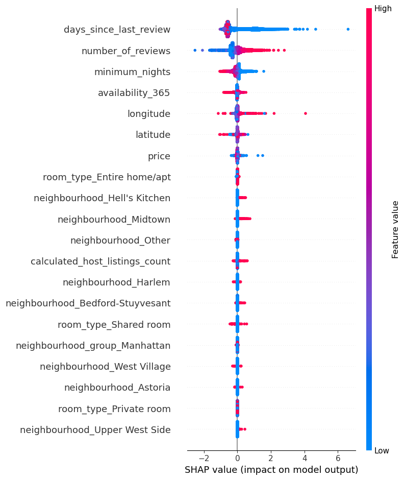

```python
shap.summary_plot(train_shap_values, X_train_enc)
```

According to the shap summary plot the features that seemed to matter the most were the top 7 of the plot. For example days_since_last review shows that when the feature values were low (fewer days since last review) were predicting a frequency of more reviews, so places that were recently reviewed are more popular. Number of reviews also played a role where the higher the feature value(more reviews) predict that it will be more popular.

## 12. Results on the test set

```python
gb_pipeline_tuned = Pipeline([
    ('preprocess', preprocessor),
    ('regressor', GradientBoostingRegressor(n_estimators=243, max_depth=5, learning_rate=0.04086904131236621, min_samples_split=6, random_state=42))
])

gb_pipeline_tuned.fit(X_train, y_train)
y_pred_test = gb_pipeline_tuned.predict(X_test)
```

```python
mse_test = mean_squared_error(y_test, y_pred_test)
rmse_test = np.sqrt(mse_test)
mae_test = mean_absolute_error(y_test, y_pred_test)
r2_test = r2_score(y_test, y_pred_test)

print(f"Test RMSE: {rmse_test:.4f}")
print(f"Test MAE: {mae_test:.4f}")
print(f"Test R²:  {r2_test:.4f}")
```

```
Test RMSE: 0.8951
Test MAE: 0.4590
Test R²:  0.6692
```

The tuned **Gradient Boosting Regressor** stayed consistent between cross-validation (Optuna objective on training folds) and the held-out test set. **Test RMSE (0.895)** is modestly higher than the best CV RMSE (**~0.847**), which is expected: the test set was not used for tuning, and a small gap suggests **good generalization** rather than severe overfitting.

**Test R² (0.669)** is higher than the mean CV R² from the initial default GBR run (**~0.59**). That comparison mixes different settings (default vs tuned model) and a single random train/test split, so a small mismatch is normal. Test R² should be compared to the **tuned** model's CV performance for a stricter check; in any case, the model explains a substantial share of variance on unseen listings.

Hyperparameter search on the training data introduces some **optimization bias** (the CV score is slightly optimistic). The workflow still respects a final **lockbox** test set for an honest estimate of deployment error.

```python
i1, i2 = 1, 10

shap.initjs()
shap.force_plot(explainer.expected_value, test_shap_values[i1].values, X_test_enc.iloc[i1,:])
```

```python
shap.force_plot(explainer.expected_value, test_shap_values[i2].values, X_test_enc.iloc[i2,:])
```

## 13. Summary of results

This project built an end-to-end **supervised regression** pipeline on the 2019 NYC Airbnb Open Data to predict **`reviews_per_month`** as a proxy for listing activity. After **EDA** (distributions, outliers, missingness) and **domain-driven cleaning** (e.g. treating zero-review listings as 0 reviews/month), we engineered **time-based features** from `last_review` (`days_since_last_review`, `never_reviewed`), applied **log transforms and scaling** to skewed numerics, and used **one-hot encoding** with **rare-level grouping** for high-cardinality `neighbourhood`. Everything was wrapped in **`sklearn` `Pipeline` / `ColumnTransformer`** to avoid leakage.

We evaluated models primarily with **RMSE** (same units as the target) and **R²**. A **dummy mean baseline** on the test set showed large error and **negative R²**, confirming the target is learnable. **Ridge** with **grid search** (`GridSearchCV`) improved substantially (CV RMSE **~1.07**, R² **~0.42**). We then compared **Random Forest**, **Gradient Boosting**, **KNN**, and **SVR** with **5-fold cross-validation**; **gradient boosting** had the best CV RMSE/R² and the healthiest **train vs validation gap**, while random forest showed stronger **overfitting** and KNN did not beat Ridge with the chosen settings.

**Hyperparameter tuning** used **Optuna** (Bayesian-style search) on the training folds; **GBR** achieved the best CV RMSE (**~0.847**) among the tuned models. The **final tuned GBR** was refit on all training data and assessed once on the **30% holdout test set**: **RMSE 0.895**, **MAE 0.459**, **R² 0.669**—clearly outperforming the linear baseline and dummy model.

**SHAP** (`TreeExplainer`) indicated that predictions lean heavily on **review history**—especially **`number_of_reviews`** and **`days_since_last_review`**—which aligns with the problem: popularity is observed through past engagement. Many location and listing-detail features contribute less at the margin, which is a useful **sanity check** but also highlights **limits of the target** (reviews/month is only a rough proxy for "popularity").

### Limitations and possible improvements

- **Optimization bias:** Tune with nested CV or a dedicated validation split if you need an unbiased estimate of CV error; keep one final test set untouched.
- **Target definition:** Explore alternatives (e.g. log-target, clipping extremes) or complementary targets; the current label mixes activity and listing age.
- **Text and identity:** Listing **`name`** was dropped; **TF–IDF** or embeddings on titles, or careful **host-level** aggregates, could add signal without leaking if designed properly.
- **Stronger learners / ensembling:** **Histogram-based boosting** (e.g. `HistGradientBoostingRegressor`, XGBoost/LightGBM) often improves tabular regression with less tuning cost.
- **Spatial/temporal validation:** If the use case is forecasting, consider **grouped splits** (e.g. by neighbourhood or time) to measure **true generalization**.
- **Uncertainty:** Add **prediction intervals** (e.g. quantile regression or conformal methods) for business decisions.

Overall, the workflow demonstrates **reproducible preprocessing**, **proper validation**, **nonlinear modeling**, **systematic hyperparameter search**, and **model interpretation**—with a final model that **generalizes well** on held-out data relative to linear and baseline competitors.